# SCnorm Tutorial

Rhonda Bacher

6/22/2018

### Download SCnorm:

```r
source("https://bioconductor.org/biocLite.R")
```

```
## Bioconductor version 3.7 (BiocInstaller 1.30.0), ?biocLite for help
```

```r
biocLite("SCnorm")
```

```
## BioC_mirror: https://bioconductor.org
```

```
## Using Bioconductor 3.7 (BiocInstaller 1.30.0), R 3.5.1 (2018-07-02).
```

```
## Installing package(s) 'SCnorm'
```

```
## Old packages: 'roxygen2'
```

```r
library(SCnorm)
```

The data included here was downloaded directly from GEO: https://www.ncbi.nlm.nih.gov/geo/query/acc.cgi?acc=GSE85917

File: GSE85917_Bacher.RSEM.xlsx

### Plot the count-depth relationship

The count-depth relationship is the dependence of read counts on the sequencing depth (total number of reads per cell). The amount each cell is sequenced is a technical artifact that affects the gene counts. Typically as cells are sequenced more, all gene counts should increase proportionally. Below is an example of a gene with a strong count-depth relationship:

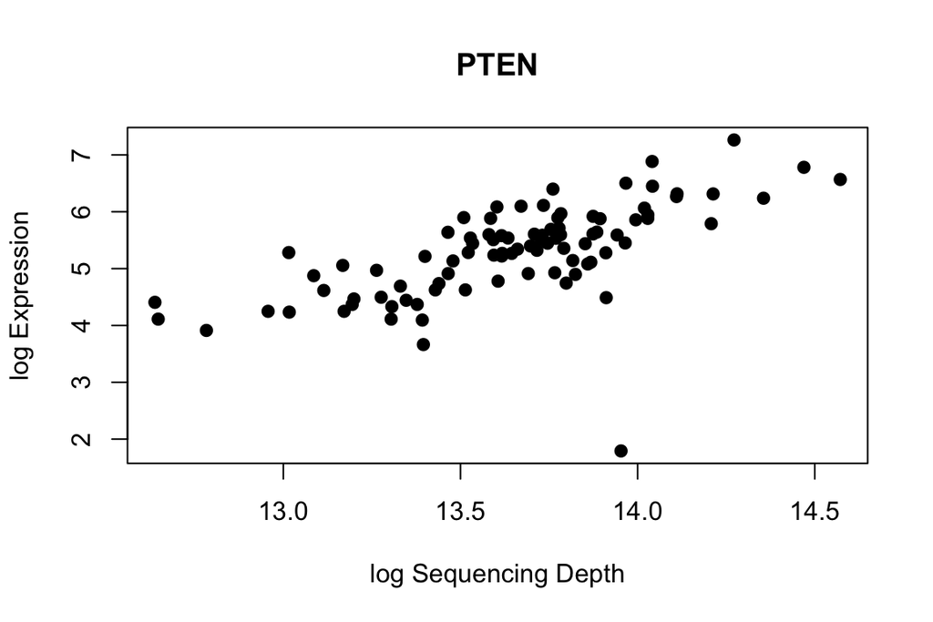

```r
seqDepth <- colSums(h1cells.1M)
plot(log(seqDepth), log(h1cells.1M["PTEN",]), pch=20, cex=1.5, xlab="log Sequencing Depth", ylab="log Expression", main="PTEN")
```

In single-cell RNA-seq not all genes have similar count-depth relationships. We see that they vary by expression level. For example, here is a gene with almost no dependence on sequencing depth:

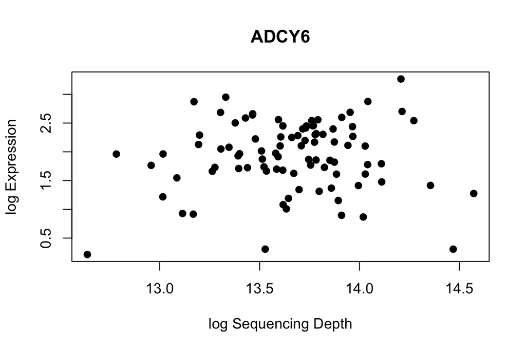

```r
seqDepth <- colSums(h1cells.1M)
plot(log(seqDepth), log(h1cells.1M["ADCY6",]), pch=20, cex=1.5, xlab="log Sequencing Depth", ylab="log Expression", main="ADCY6")
```

The count-depth relationship is estimated for every gene by SCnorm using a median quantile regression on the non-zeros:

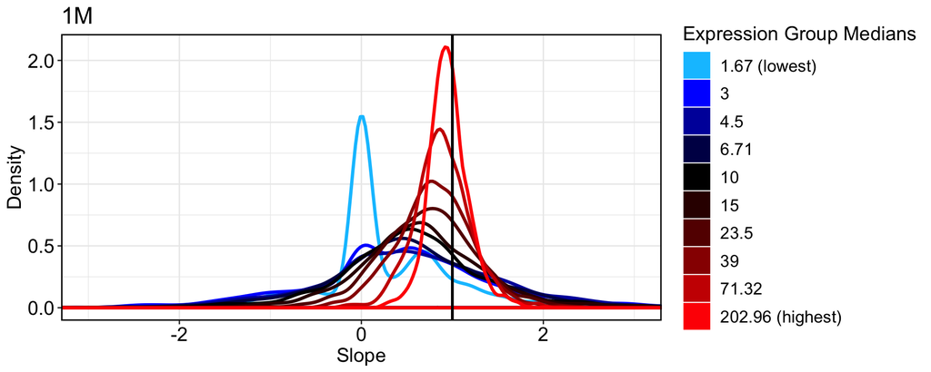

```r
h1cells.1M <- data.matrix(h1cells.1M)
cdr.1M <- plotCountDepth(Data = h1cells.1M, Conditions = rep("1M", ncol(h1cells.1M)))
```

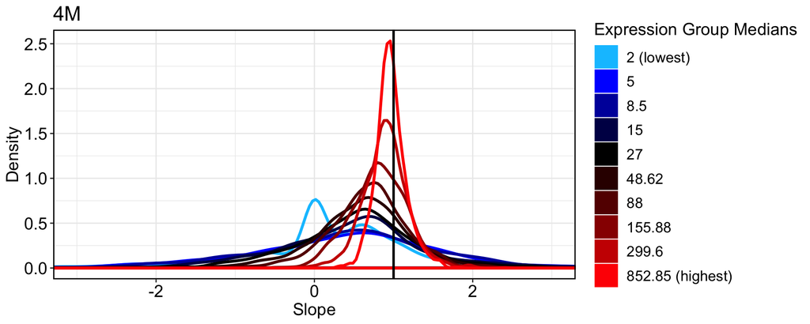

```r
h1cells.4M <- data.matrix(h1cells.4M)
cdr.4M <- plotCountDepth(Data = h1cells.4M, Conditions = rep("4M", ncol(h1cells.4M)))
```

Other normalization methods estimate only one scale factor per cell. When the count-depth relationship varies this is not ideal and leads to poor normalization. For example if we apply a total count normalization method, i.e. CPM (Counts Per Million):

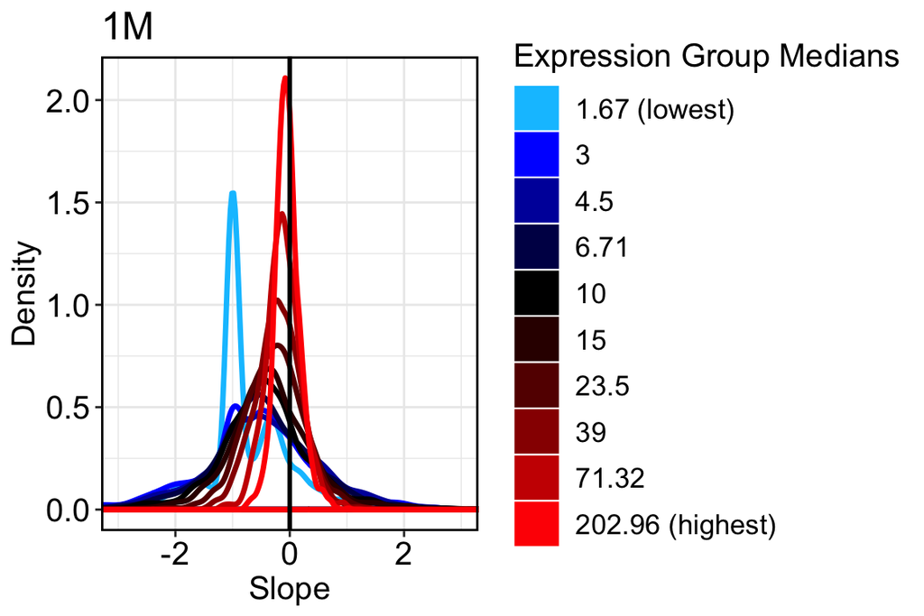

```r
scaleFactors <- colSums(h1cells.1M) / 1e6
norm.h1cells.1M = t(t(h1cells.1M)/scaleFactors)

cdr.1M.norm <- plotCountDepth(Data = h1cells.1M, NormalizedData =  norm.h1cells.1M, Conditions = rep("1M", ncol(h1cells.1M)))
```

Clearly the slopes are not all equal to zero. This is also obvious if we look at individual genes that are under- and over- normalized:

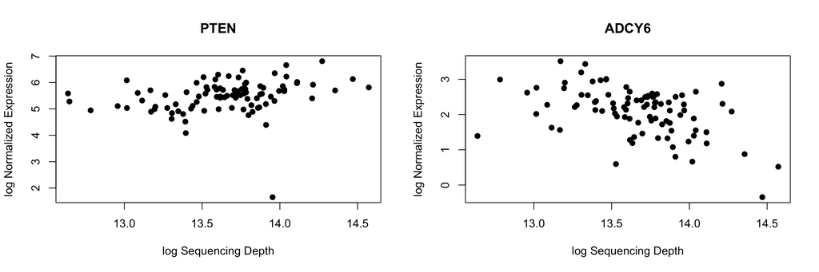

```r
seqDepth <- colSums(h1cells.1M)
par(mfrow=c(1,2))
plot(log(seqDepth), log(norm.h1cells.1M["PTEN",]), pch=20, cex=1.5, xlab="log Sequencing Depth", ylab="log Normalized Expression", main="PTEN")
plot(log(seqDepth), log(norm.h1cells.1M["ADCY6",]), pch=20, cex=1.5, xlab="log Sequencing Depth", ylab="log Normalized Expression", main="ADCY6")
```

[output not shown]

To normalize the data using SCnorm, each gene will be placed into a group based on its count-depth relationship. The normalization is an iterative process, and the number of groups starts at K = 1. For each value of K, the normalized count-depth relationship is evaluated and if most genes are near zero then the current K is sufficient. If not, then K is increased to K + 1.

```
## Setting up parallel computation using 3 cores
```

```
## Gene filter is applied within each condition.
```

```
## 5948 genes in condition 1M will not be included in the normalization due to
##              the specified filter criteria.
```

```
## A list of these genes can be accessed in output,
##     see vignette for example.
```

```
## Finding K for Condition 1M
```

```
## Trying K = 1
```

```
## Trying K = 2
```

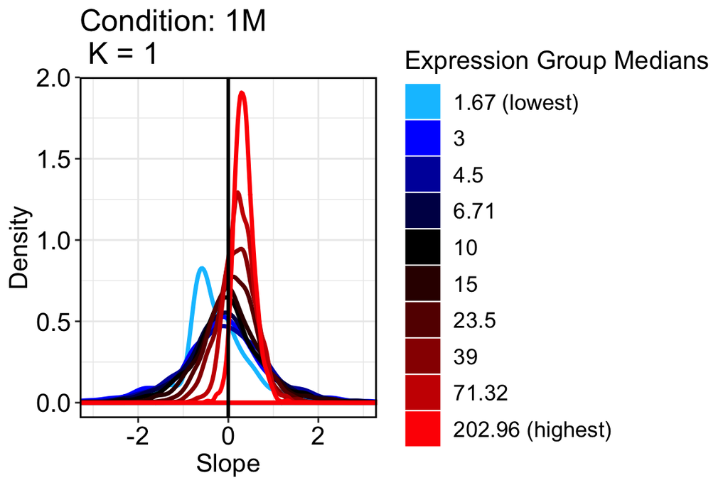

```
## Trying K = 3
```

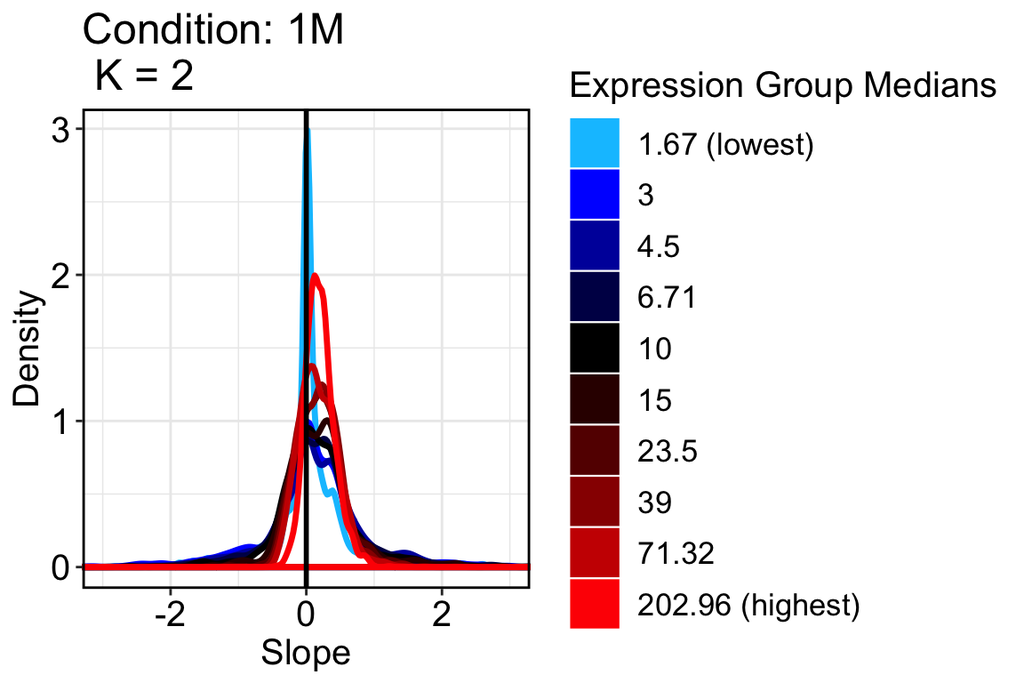

```
## Done!
```

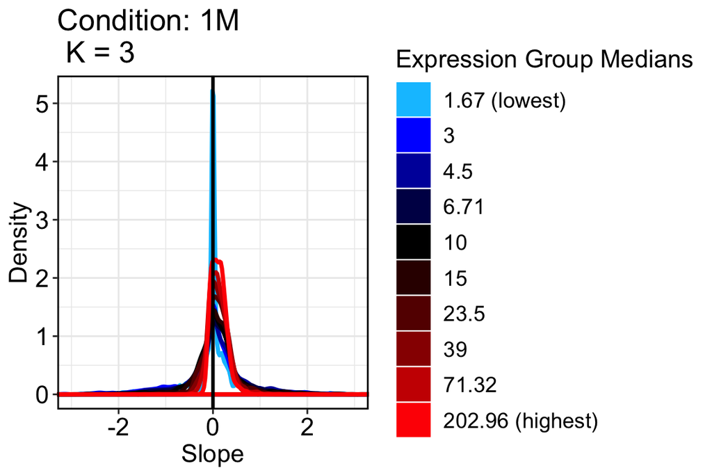

```r
Conditions <- rep("1M", ncol(h1cells.1M))
myNormData <- SCnorm(Data = h1cells.1M, Conditions = Conditions, PrintProgressPlots = TRUE, reportSF = TRUE)
```

The normalized data is assessible through the results function:

```r
library(SingleCellExperiment)
normData <- normcounts(myNormData)
genesOUT <- results(myNormData, type = c("GenesFilteredOut"))
scaleFactors <- results(myNormData, type = c("ScaleFactors"))
```